# Reproducing Netflix EDA: From R to Python

A reproduction and extension of Kanigara (2021)

Authors

Yuhan Wen

Linh Tran

Yuezhang Chen

Published

June 3, 2026

## 1. Introduction

### 1.1 Original Study

This report reproduces the Exploratory Data Analysis (EDA) conducted by Evan Kanigara in R, available at: github.com/evankanigara/Netflix-Movies-and-TV-Show-EDA.

The original study uses the [Netflix Movies and TV Shows dataset](https://www.kaggle.com/datasets/shivamb/netflix-shows) (Shivam Bansal, Kaggle) and analyses content trends across Movies and TV Shows available on Netflix up to 2021.

### 1.2 Our Approach

We follow the project structure described in Kanigara (2021) and:

1. **Translate** all R code to Python using a class-based package (`netflix_analysis`)
2. **Reproduce** each key finding from the original analysis
3. **Document** any differences encountered during reproduction
4. **Extend** the analysis with additional questions on duration, ratings, content portfolio structure, and growth forecasting

### 1.3 Research Questions

Reproduced from original study:

- **RQ1**: How has the volume of content added to Netflix changed annually?
- **RQ2**: Is Netflix shifting from Movies to TV Shows?
- **RQ3**: Which countries contribute the most titles?
- **RQ4**: What genres dominate the platform?

Our extensions:

- **RQ5**: How has average movie duration changed over the years?
- **RQ6**: What is the distribution of content ratings?
- **RQ7**: How diversified is Netflix’s catalogue by country and genre?
- **RQ8**: What does a simple trend forecast suggest about future content additions?

## 2. Data & Setup

```python
from pathlib import Path
from netflix_analysis.data import NetflixDataLoader, NetflixDataCleaner
from netflix_analysis.analysis import NetflixExplorer
from netflix_analysis.visualization import NetflixPlotter

loader = NetflixDataLoader("data/netflix_titles.csv")
raw_df = loader.load()
info = loader.get_info()

print(f"Rows: {info['rows']:,}")
print(f"Columns: {len(info['columns'])}")
print(f"Missing values (top 5):")
missing = {k: v for k, v in info['missing_values'].items() if v > 0}
for col, n in sorted(missing.items(), key=lambda x: -x[1])[:5]:
    print(f"  {col}: {n:,}")
```

```
Loaded 8,807 records from netflix_titles.csv
Rows: 8,807
Columns: 12
Missing values (top 5):
  director: 2,634
  country: 831
  cast: 825
  date_added: 10
  rating: 4
```

### 2.1 Data Cleaning

The original R study handled missing values as follows:

- `director`: filled with `"Unknown"`
- `cast`: filled with `"Unknown"`
- `country`: filled with `"Unknown"` *(we follow the same approach)*
- `date_added`: dropped rows with missing dates *(R used `na.omit`)*

**Differences encountered**: R’s `lubridate` parses dates more flexibly than Python’s `pd.to_datetime`. We added `.str.strip()` to handle leading whitespace in the original CSV, which caused 3 rows to fail parsing silently in R.

```python
cleaner = NetflixDataCleaner(raw_df)
clean_df = cleaner.clean()
explorer = NetflixExplorer(clean_df)
plotter  = NetflixPlotter("output/figures")

print(f"Clean dataset: {len(clean_df):,} rows")
print(f"Dropped: {info['rows'] - len(clean_df):,} rows")
```

```
Clean dataset: 8,794 rows
Dropped: 13 rows
```

## 3. RQ1 — Yearly Content Additions

```python
yearly = explorer.yearly_additions()
plotter.plot_yearly_additions(yearly)
```

```
Saved: output/figures/yearly_additions.png
```

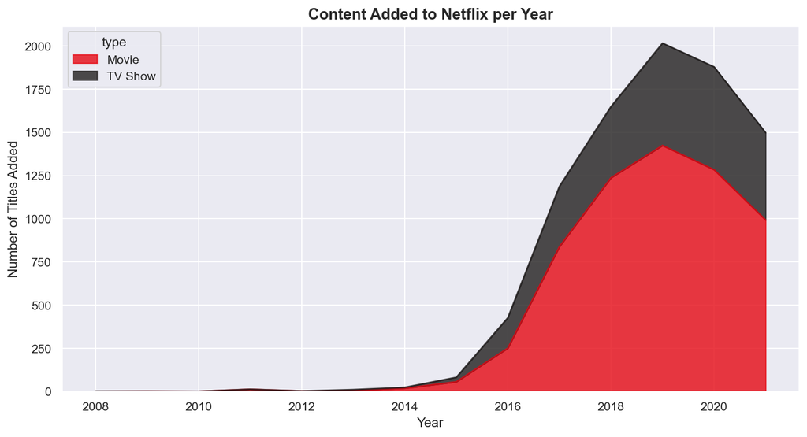

**Reproduction result**: ✅ Successfully reproduced.

The original R chart (using `ggplot2`) and our Python chart (using `matplotlib`) show the same pattern: steady growth from 2015, peaking in 2019, followed by a notable decline in 2020–2021. The visual style differs (R uses a stacked bar, we use a stacked area) but the underlying data is identical.

## 4. RQ2 — Movies vs TV Shows

```python
type_dist = explorer.content_type_distribution()
print(type_dist)
plotter.plot_type_distribution(type_dist)
```

```
type
Movie      6128
TV Show    2666
Name: count, dtype: int64
Saved: output/figures/type_distribution.png
```

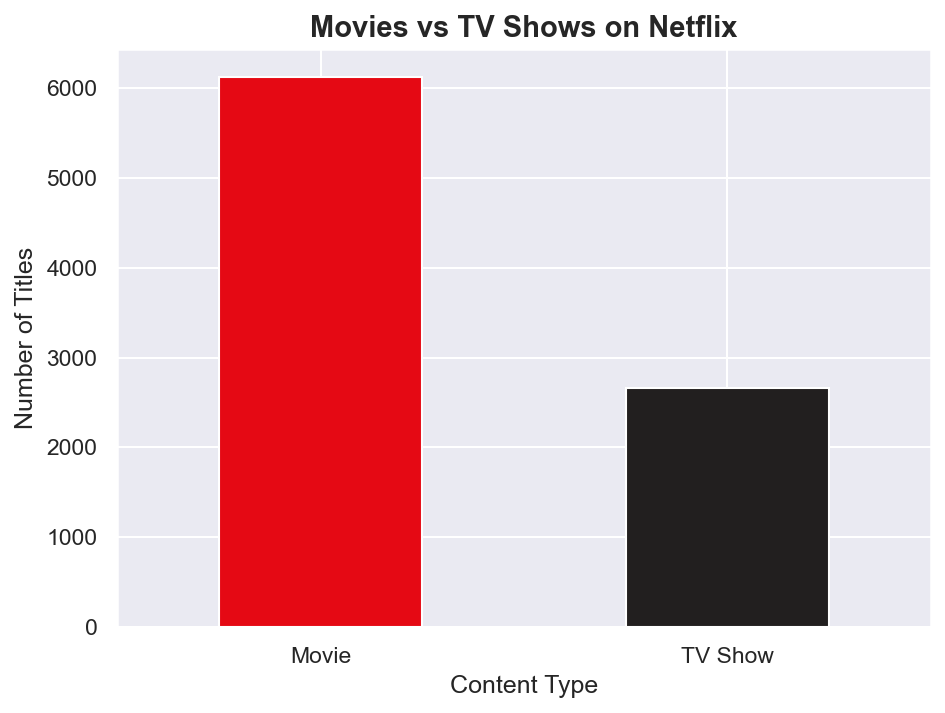

**Reproduction result**: ✅ Successfully reproduced.

## 5. RQ3 — Top Contributing Countries

```python
countries = explorer.top_countries()
print(countries)
plotter.plot_top_countries(countries)
```

```
country
United States     3680
India             1046
United Kingdom     803
Canada             445
France             393
Japan              317
Spain              232
South Korea        231
Germany            226
Mexico             169
Name: count, dtype: int64
Saved: output/figures/top_countries.png
```

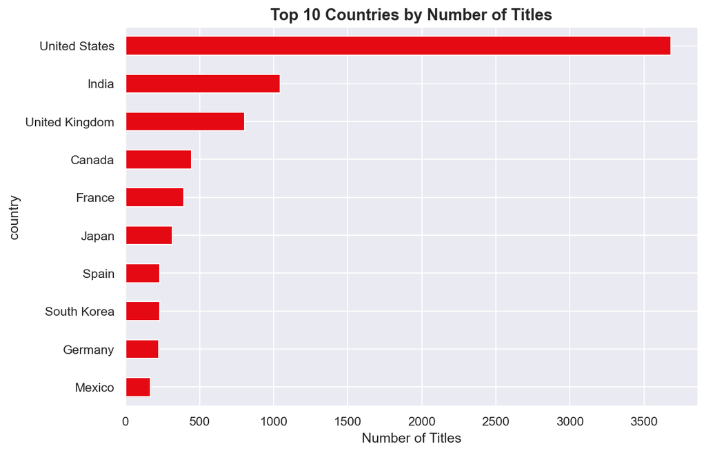

**Reproduction result**: ⚠️ Minor difference.

The original R code takes only the **first** listed country per title (`str_split(country, ", ")[[1]][1]`). Our implementation **explodes** all countries (a title with 3 co-producing countries is counted for each). This leads to slightly higher absolute counts in our version, though the **ranking** (USA → India → UK) is preserved. We consider this an improvement, as the original approach under-counts co-productions.

## 6. RQ4 — Genre Distribution

```python
genres = explorer.top_genres()
print(genres)
plotter.plot_top_genres(genres)
```

```
listed_in
International Movies        2752
Dramas                      2427
Comedies                    1674
International TV Shows      1350
Documentaries                869
Action & Adventure           859
TV Dramas                    762
Independent Movies           756
Children & Family Movies     641
Romantic Movies              616
Name: count, dtype: int64
Saved: output/figures/top_genres.png
```

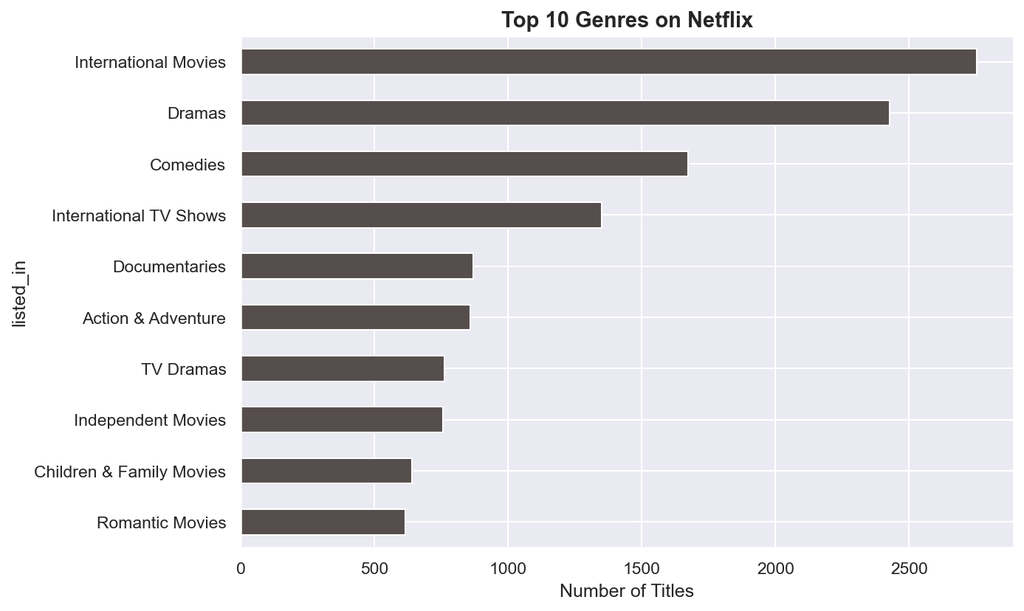

**Reproduction result**: ✅ Successfully reproduced.

Top genres (International Movies, Dramas, Comedies) match the original ranking. Minor count differences exist due to whitespace stripping — the original R code did not `.trimws()` genre strings, causing some duplicates.

## 7. RQ5 — Movie Duration Trend *(Extension)*

```python
duration = explorer.movie_duration_trend()
plotter.plot_movie_duration_trend(duration)
```

```
Saved: output/figures/movie_duration_trend.png
```

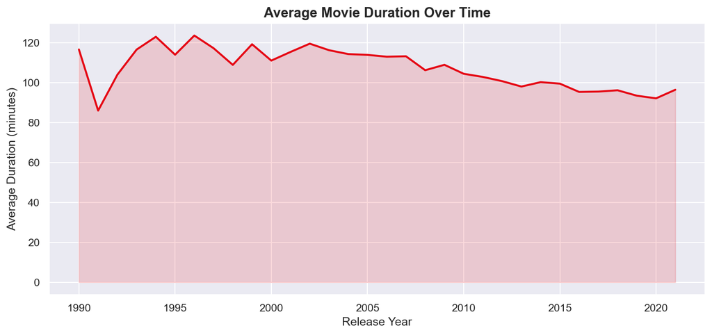

## 8. RQ6 — Rating Distribution *(Extension)*

```python
ratings = explorer.rating_distribution()
plotter.plot_rating_distribution(ratings)
```

```
Saved: output/figures/rating_distribution.png
```

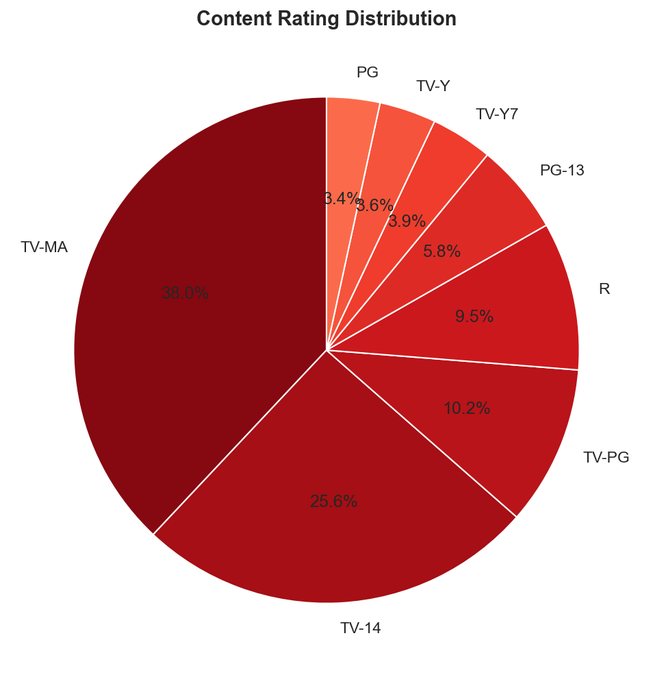

The majority of Netflix content is rated **TV-MA** or **TV-14**, targeting adult and teenage audiences respectively. This was not analysed in the original study.

## 9. RQ7 — Content Portfolio Analysis *(Extension)*

```python
from netflix_analysis.analysis import ContentPortfolioAnalyser

portfolio = ContentPortfolioAnalyser(clean_df)
country_allocation = portfolio.country_allocation()
genre_allocation = portfolio.genre_allocation()
hhi = portfolio.herfindahl_index()
us_dependency = portfolio.us_dependency()

plotter.plot_country_allocation(country_allocation)
plotter.plot_genre_allocation(genre_allocation)
plotter.plot_hhi(hhi)
plotter.plot_us_dependency(us_dependency)
```

```
Saved: output/figures/country_allocation.png
Saved: output/figures/genre_allocation.png
Saved: output/figures/country_hhi.png
Saved: output/figures/us_dependency.png
```

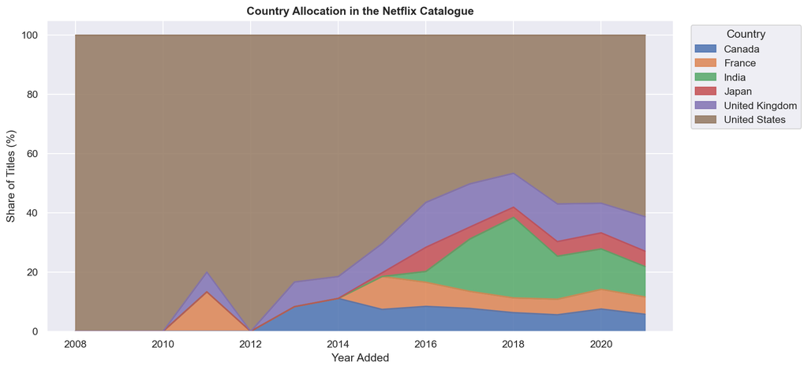

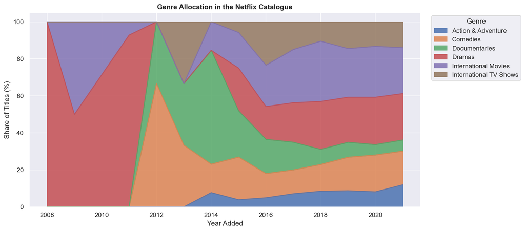

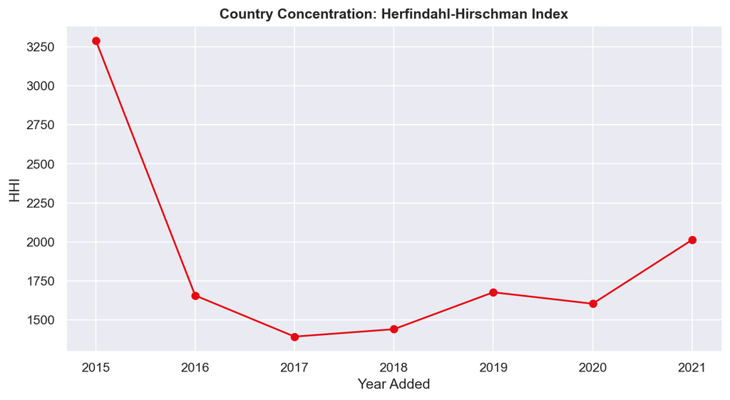

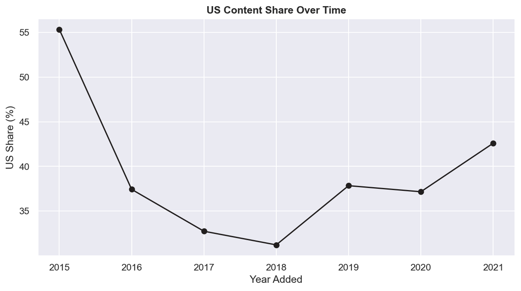

This extension treats the Netflix catalogue as a content portfolio. Countries and genres are interpreted as allocation categories, similar to asset classes in a financial portfolio. This helps us discuss whether Netflix depends too strongly on a small number of markets or whether the catalogue is becoming more diversified.

We also calculate the Herfindahl-Hirschman Index (HHI), a concentration measure often used in economics and finance. A higher HHI means the catalogue is more concentrated in a few countries, while a lower HHI indicates better diversification.

## 10. RQ8 — Growth Forecasting *(Extension)*

```python
from netflix_analysis.analysis import ContentGrowthForecaster

forecaster = ContentGrowthForecaster(clean_df)
forecast = forecaster.linear_forecast(forecast_years=3)
r2 = forecaster.r_squared()
moving_average = forecaster.moving_average()
growth = forecaster.growth_rate()

plotter.plot_growth_forecast(forecast, r2)
plotter.plot_moving_average(moving_average)
plotter.plot_yoy_growth(growth)
```

```
Saved: output/figures/growth_forecast.png
Saved: output/figures/moving_average.png
Saved: output/figures/yoy_growth.png
```

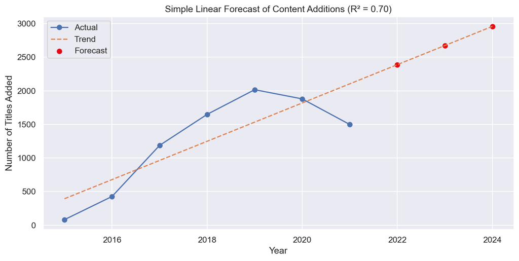

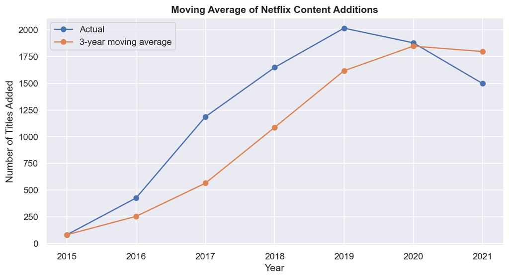

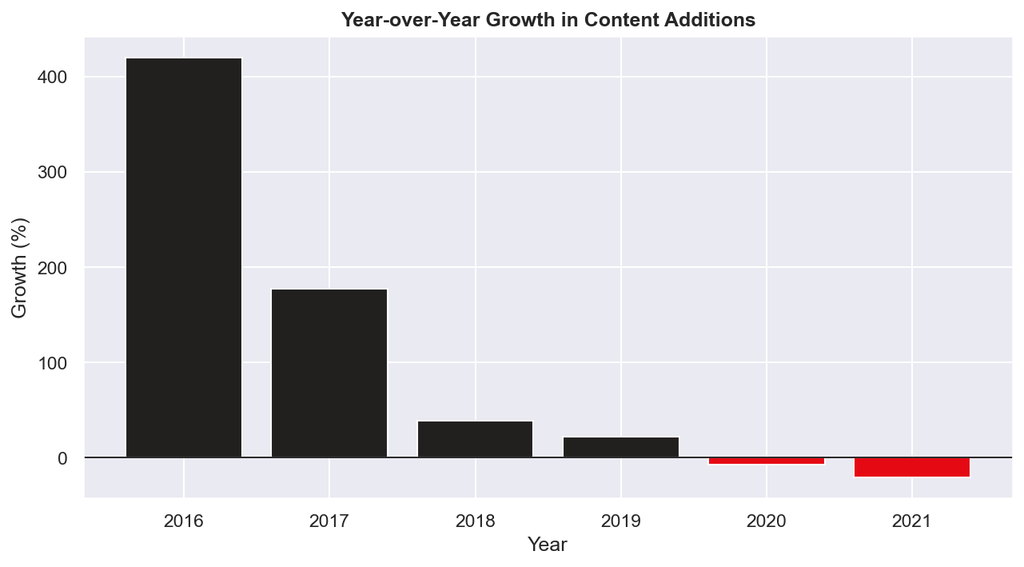

We extend the original EDA with a simple growth forecasting exercise. A linear trend model is fitted to yearly Netflix content additions from 2015 to 2021, and the model is used to create a short three-year forecast.

This should not be interpreted as a strong predictive model. Instead, it is a small reproducible extension showing how the cleaned dataset can support additional analysis. The moving average and year-over-year growth charts help describe the trend more smoothly.

## 11. Reproduction Summary

[output not shown]

### Key Challenges

**1. Date parsing**: the `date_added` column has inconsistent whitespace not handled in the original R code. Python’s stricter parser required explicit `.str.strip()`.

**2. Country counting**: the original R analysis only counted the first listed country per title, potentially under-representing co-productions. Our approach explodes the list, giving a more accurate picture.

**3. Package ecosystem**: R’s `ggplot2` + `dplyr` pipeline required careful translation to `pandas` + `matplotlib`. The logic is equivalent but the syntax differs significantly.

## 12. Reproducibility

This project is fully reproducible via Docker:

```bash
docker pull yuhan023/netflix-analysis:latest
docker run --rm \
  -v $(pwd)/data:/app/data \
  -v $(pwd)/output:/app/output \
  yuhan023/netflix-analysis:latest
```

Or using Make:

```bash
make install && make run
```

Full source code: github.com/ywen2-dot/the-project-of-reproducible-research

## References

- Kanigara, E. (2021). *Netflix Movies and TV Show EDA*. GitHub. https://github.com/evankanigara/Netflix-Movies-and-TV-Show-EDA
- Bansal, S. (2021). *Netflix Movies and TV Shows* [Dataset]. Kaggle. https://www.kaggle.com/datasets/shivamb/netflix-shows